# Selecting points with rMultivariateMatching

## Introduction

This vignette describes a workflow for selecting an optimal subset of sites `k` from within a study area using the `kpoints` function, such that the `k` sites maximize the area represented by a minimum number of sites (**subset cells**). The method was designed to select optimal sites for simulation, for the purpose of applying the interpolation function `interpolatePoints` to interpolate simulation output from the **subset cells** to create high-resolution maps of output variables across the study area (**target cells**). The site selection method is meant to balance the cost of adding more sites (in terms of computational or other resources) with the benefit of representing a larger proportion of the study area. Importantly, the site selection method could also be used to select an optimal set of sites for field sampling. Here, we illustrate the workflow for site selection using an example for the state of Wyoming. The code chunks in this document are meant to be run sequentially. Data relevant to this example are contained within the `rMultivariateMatching` package. The site-selection method is described in:

> Renne, R. R., Schlaepfer, D. R., Palmquist, K. A., Lauenroth, W. K., & Bradford, J. B. In preparation. Estimating complex ecological variables at high resolution in heterogeneous terrain using a multivariate matching algorithm.

### Examples of the site selection and interpolation methods in print

In the site selection example in *Renne et al.*, our goal was to project the impacts of climate change, wildfire, and lifestock grazing on big sagebrush (*Artemisia tridentata*) plant communities in the western United States using STEPWAT2, an individual-based, gap dynamics plant simulation model (Palmquist, Bradford et al., 2018; Palmquist, Schlaepfer et al., 2018). So, we chose a set of six climate variables that capture the major drivers of plant community structure in drylands as matching variables. We used the site selection interpolation methods described in *Renne et al.* to generate the maps of simulation output for a recent publication investigating the projected impacts of climate change on big sagebrush plant communities:

> Palmquist, K. A., Schlaepfer, D. R., Renne, R. R., Torbit, S. C., Doherty, K. E., Remington, T. E., Watson, G., Bradford, J. B., & Lauenroth, W. K. (2021). Divergent climate change effects on widespread dryland plant communities driven by climatic and ecohydrological gradients. *Glob. Change Bio.*, 27(20), 5169-5185. https://doi.org/10.1111/gcb.15776

Interpolated datasets from the study are available from the US Geological Survey Sciencebase:

> Renne, R. R., Palmquist, K. A., Schlaepfer, D. R., Lauenroth, W. K., and Bradford, J. B. (2021). *High-resolution maps of big sagebrush plant community biomass using multivariate matching algorithms: U.S. Geological Survey data release.* https://doi.org/10.5066/P9MNKWS4.

## Overview and definitions

The functions in the `rMultivariateMatching` package measure similarity between sites as the Euclidean distance of standardized (i.e., weighted) **matching variables**. Each variable is standardized by dividing it by the maximum amount of difference that would still allow two sites to be considered analogous for that variable. These maximum differences are called the **matching criteria** for each variable. For example, if two sites could be reasonably considered analogous as long as they were within 50 mm of each other for mean annual precipitation (MAP), the matching criteria for MAP could be set to 50 mm. Distances are calculated within the `rMultivariateMatching` function using the `distances` package (Savje 2019).

### Definitions

- **subset cells** A subset of sites (selected using `kpoints` or determined from some other method) for simulation. Sites are defined geographically as the centroid of the raster cells that they represent.
- **target cells** All cells across a study area.
- **matching variables** A set of variables relevant to the ecosystem and simulation model that are used to determine similarity between sites. Matching variables must be available as rasters covering the entire study area.
- **matching criteria** Maximum allowable differences between Target and matched Subset cells for each matching variable such that sites can be considered analogous.
- **kpoints** Site selection algorithm that uses multivariate clustering based on the unsupervised classification scheme, *k-means* (MacQueen 1967), to find groups of analogous sites across a study area.

The figure below illustrates an overview of the site selection and interpolation methods and key terminology. First, a set of **matching variables** are selected and standardized using user-defined **matching criteria**. Next, the `kpoints` algorithm is used to determine an optimal set of *k* **subset cells** for use in field sampling or simulation. All **target cells** are matched to one of the **subset cells** (matches are denoted by color in central panel). Finally, oint results (e.g., simulation output) for the **subset cells** are interpolated across the study area using multivariate matching to produce continuous, high-resolution maps of output, such as plant functional type biomass or ecohydrological variables.

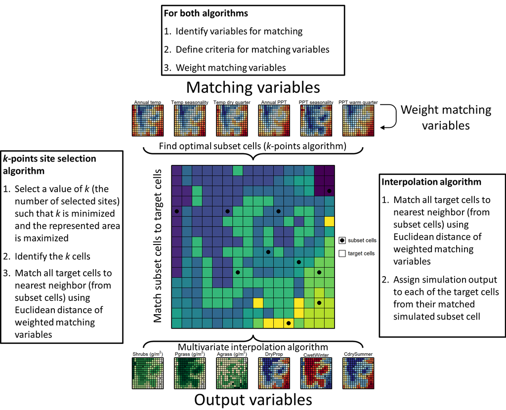

```r
library(rMultivariateMatching)
```

## Overview of the kpoints function

In the `kpoints` function, *k* sites (**subset cells**) are randomly selected from all cells in the study area (**target cells**). Then, each **target cell** is assigned to a group according to its nearest neighbor among the **subset cells** using Euclidean distance of the weighted (standardized) **matching variables**. As a result, all **target cells**, whether part of the random selection of *k* cells or not, are assigned to a group. Next, the centroids (multivariate mean) of the groups are calculated and the **target cell** that is the nearest neighbor to the centroid of each group is selected as one of an updated set of **subset cells**. Again, each **target cell** is assigned to a group according to its nearest neighbor among the current selection of *k* **subset cells** and the process continues until a stopping criterion is met: either 1) a predefined number of iterations are completed (`iter` parameter in the `kpoints` function) or the change in area represented between iterations is at or below a designated threshold (`min_area` parameter in the `kpoints` function) for five consecutive iterations.

Importantly, because the proportion of the area represented by the *k* **subset cells** may increase or decrease between consecutive iterations, the last iteration before stopping may not represent the best solution. However, once a stopping criterion is met, the **subset cells** for the iteration that represented the largest proportion of the study area are saved as the best solution.

Stopping criteria are designed to stop the algorithm when an optimal solution has been found (little to no gain in represented area for additional iterations) and to prevent the algorithm from running indefinitely, i.e., it will stop after the designated number of iterations (`iter`), whether or not an optimal solution has been found. Because the algorithm may stop prior to finding an optimal solution, suitable values for `iter` and `min_area` should be determined to ensure that the change in area represented by each iteration levels out before stopping (set `verify_stop` to `TRUE`). See Verify stopping criteria below.

In addition to the stopping criteria, the `n_starts` argument in the `kpoints` function can have a strong influence on the quality of the results. The solution is likely to vary depending on the initial random selection of cells, and similar to the *kmeans* clustering algorithm (MacQueen 1967), `kpoints` can get “stuck” in a locally optimal solution that falls short of the globally optimal solution. What that means in our case, is that running the `kpoints` function with a single random selection of `k` cells (`n_starts` = 1) is likely to result in a selection of `k` points that does not represent as much of the study area as is possible for that number of points. Thus, to increase the probability that `kpoints` will find a solution that represents as much of the study areas as possible for that value of `k`, we need to try multiple initiations of the algorithm with different initial random selections of **target cells**. This can be achieved by setting `n_starts` argument to a value > 1. The default value is 10 and values <10 will throw a warning (but still run). A reasonable number of starts for testing **matching criteria** and determining the optimal value of `k` would be 10. When you are ready to find the final selection of **subset cells** using `kpoints`, you should set `n_starts` to a relatively large number: `n_starts` = 100 should be adequate, and you may choose a higher number if you wish.

Importantly, the `kpoints` function can take some time to run, particularly if `n_starts` is large, when solving over a large range of possible values of `k`, and when working with a large study area or with many **matching variables**. Because of possibly long run times, `kpoints` generates text output at the start of each iteration that reports the time, *i* of `iter`, `k`, and *n* of `n_starts`, followed by text output at the end of each iteration that reports *i* of `iter`, *n* of `n_starts`, `k`, and coverage (both in $km^{2}$ and as a percentage of total area).

## Identify variables for matching, selecting matching criteria, and determining the optimal number of points

The first step is to identify the **matching variables**. This will depend on the data that are available and the ecosystem and processes in question. **Matching variables** must be provided as a stack of rasters (`rasterStack`, see the `raster` package (Hijmans 2021) for details).

Once you have identified your **matching variables**, you will need to convert the rasterStack to a data frame that can be used in subsequent functions in the `rMultivariateMatching` package. Importantly, it can be useful to include other variables that are not for matching but are still relevant to the ecosystem and processes in question so that you can use these to evaluate matching (using the `evaluateMatching` function) later on.

### Prepare input data

The `makeInputdata` function takes the rasterStack of matching (and other) variables and transforms it into the correct format to be used in subsequent functions.

```r
# Load targetcells data for Target Cells
data(targetcells)

# Create data frame of potential matching variables for Target Cells
allvars <- makeInputdata(targetcells)
```

### Choose matching criteria to standardize matching variables

The `choose_criteria` function runs through a list of vectors of **matching criteria** and calculates the proportion of areal coverage of each set. You can compare the areal coverage across the sets to determine an acceptable balance between how strict the **matching criteria** are and the proportion of the study area that can be represented by a given number of `k` points. Importantly, you will need to choose a value for `k` (number of **subset cells**) to run this function, which may need to be somewhat arbitrary if you have not yet run `kpoints` over a range of possible values of `k` to determine the optimal number of points.

Typically, determining **matching criteria** and `k` will involve some experimentation by running `kpoints` over a range of possible values for `k` with different sets of **matching criteria**. In the example below, we have set `k` to 200.

```r
# Restrict data to matching variables of interest
matchingvars <- allvars[,c("cellnumbers","x","y","bioclim_01","bioclim_04",
                           "bioclim_09","bioclim_12","bioclim_15","bioclim_18")]

# Create list of matching criteria to choose:
# Look at 2.5%, 5%, & 10% of range and standard deviation for each variable
range2.5pct <- apply(matchingvars[,4:ncol(matchingvars)],2,
                     function(x){(max(x)-min(x))*0.025})
range5pct <- apply(matchingvars[,4:ncol(matchingvars)],2,
                     function(x){(max(x)-min(x))*0.05})
range10pct <- apply(matchingvars[,4:ncol(matchingvars)],2,
                     function(x){(max(x)-min(x))*0.1})
stddev <- apply(matchingvars[,4:ncol(matchingvars)],2,sd)

# Create criteria_list
criteria_list <- list(range2.5pct, range5pct, range10pct, stddev)
```

#### Table displaying the criteria list

| bioclim_01 | bioclim_04 | bioclim_09 | bioclim_12 | bioclim_15 | bioclim_18 |
| --- | --- | --- | --- | --- | --- |
| 0.36 | 10.62 | 0.82 | 32.97 | 1.36 | 4.61 |
| 0.73 | 21.23 | 1.64 | 65.93 | 2.72 | 9.21 |
| 1.45 | 42.47 | 3.29 | 131.86 | 5.44 | 18.42 |
| 2.49 | 60.37 | 7.41 | 170.74 | 13.53 | 34.27 |

### Explanation of `choose_criteria` arguments

Please also refer to the `choose_criteria` documentation.

- `matchingvars` A data frame representing all **target cells** from which a subset of `k` points will be selected. This data frame can be created using the `makeInputdata` function.
- `criteria_list` A list of vectors of **matching criteria** to be tested.
- `n_starts` The number of random selections of **target cells** to use for initializing different runs of the `kpoints` algorithm (as discussed above).
- `k` The number of **subset cells** to select using the `kpoints` function.
- `verify_stop` This is a boolean that indicates whether or not a figure displaying the proportion of the study area represented for each iteration of each *n* of `n_starts` should be displayed. This argument is used to verify that the stopping criteria are appropriate. See above for details.
- `raster_template` This is one of the rasters used to define the **target cells** and it is used as a template to determine the area represented by each iteration and by the solution for each of the `n_starts`. This argument is fundamental to the `kpoints` function because `kpoints` is designed to optimize based on represented area.
- `subset_in_target` A boolean indicating if the **subset cells** are taken from within the **target cells**. When the `kpoints` function is used to select the **subset cells**, this will be `TRUE` (as is the case in this example).
- `plot_coverage` A boolean indicating if the proportion of the study area represented by each vector of **matching criteria** in the `criteria_list` should be displayed in a bar plot. (Set to `FALSE` in this example).

**Note:** the function below does not specify several additional arguments that are passed to the `kpoints` function (meaning default values will be used):

- `min_area` Default is 50.
- `n_starts` Default is 10.
- `iter` Default is 50.

```r
# Compare coverage with various criteria
results2 <- choose_criteria(matchingvars, criteria_list = criteria_list,
                            n_starts = 10, k = 200, verify_stop = FALSE,
                            raster_template = targetcells[[1]],
                            subset_in_target = TRUE,
                            plot_coverage = FALSE)
```

### Explanation of `choose_criteria` outputs

The output from the `choose_criteria` function is a named list where the first item (‘totalarea’) reports the total area in $km^2$ of the **target cells** and the second item (‘solution_areas’) reports the area represented (Euclidean distance of weighted **matching variables** $\le 1$ between **target** and matched **subset cells**) for each set of **matching criteria**.

In the above example, `plot_coverage` is set to `FALSE`. If `TRUE`, the `choose_criteia` function will generate a barplot that shows the proportion of the study area that is represented by each set of matching criteria in `criteria_list`. You can also set `plot_coverage` to `FALSE` and use the `criteriaplot` function to visualize the results of the `choose_criteria` function, as shown below.

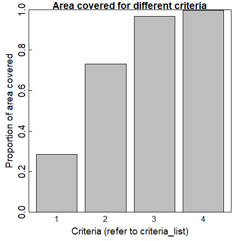

```r
# Plot coverage
criteriaplot(results2, criteria_list)
```

### kpoints

The `kpoints` function uses a data frame created using `makeInputdata` to determine multivariate clusters of analogous sites (**target cells**) and select one site to represent each cluster (**subset cells**). The number of clusters is designated as `k`. The optimal value of `k` can be determined by running the `kpoints` function for a series of possible `k` values and evaluating the change in the proportion of the study area that is represented as `k` increases. The proportion of the study area that is represented by the `k` points will increase with `k`, and `k` can be chosen by identifying where along the range of `k` the benefit of increasing represented area is outweighed by the cost associated with adding additional sites.

### Determine k: the optimal number of points

To illustrate the process of choosing a value for `k` below, we test a range of `k` values from 25 to 100 in steps of 25. First, we run the `kpoints` function for this range of values saved as a vector called `klist`. Then, we plot the proportion of the study area covered by each `k` value as a function of `k` using the `plotcoverage` function.

Importantly, you will need to select a set of **matching criteria** to use the `kpoints` function to choose a value for `k`, which may need to be somewhat arbitrary if you have not yet run the `choose_criteria` function to determine the best set of criteria for your project.

Typically, determining **matching criteria** and `k` will involve some experimentation by running `kpoints` over a list of possible values for `k` with different sets of **matching criteria**. In the example below, we have set the **matching criteria** as either 5 or 10% of the range of each of the matching variables. Importantly, before we run `kpoints` to select our final set of **subset cells**, we run `kpoints` for a single value for `k` and set `verify_stop` to `TRUE` (without saving the output to an object) so that we can verify that the stopping criteria are appropriate. More information on verifying stopping criteria can be found below.

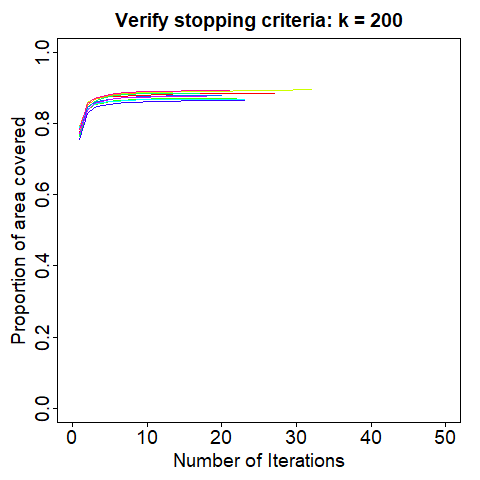

```r
# Create vector of matching criteria
criteria <- c(0.7,42,3.3,66,5.4,18.4)
# Verify stopping criteria
kpoints(matchingvars, criteria = criteria, klist = 200,
                    n_starts = 10, min_area = 50, iter = 50,
                    raster_template = targetcells[[1]], verify_stop = TRUE)
```

### Explanation of `kpoints` arguments

Please also refer to the `kpoints` documentation.

- `matchingvars` A data frame representing all **target cells** from which a subset of `k` points will be selected. This data frame can be created using the `makeInputdata` function.
- `criteria` A vector of **matching criteria** that correspond to each **matching variable** in the `matchingvars` data frame.
- `n_starts` The number of random selections of **target cells** to use for initializing different runs of the `kpoints` algorithm (as discussed above).
- `min_area` and `iter` Stopping criteria. Detailed explanation of these arguments provided above.
- `klist` A vector of a range of values of **subset cells** to select using the `kpoints` function.
- `verify_stop` This is a boolean that indicates whether or not a figure displaying the proportion of the study area represented for each iteration of each *n* of `n_starts` should be displayed. This argument is used to verify that the stopping criteria are appropriate. See above for details.
- `raster_template` This is one of the rasters used to define the **target cells** and it is used as a template to determine the area represented by each iteration and by the solution for each of the `n_starts`. This argument is fundamental to the `kpoints` function because `kpoints` is designed to optimize based on represented area.
- `subset_in_target` A boolean indicating if the **subset cells** are taken from within the **target cells**. When the `kpoints` function is used to select the **subset cells**, this will be `TRUE` (as is the case in this example).

```r
# Create sequence of values for k
klist = seq(25,100, by = 25)
# Run kpoints algorithm for klist
results3 <- kpoints(matchingvars, criteria = criteria, klist = klist,
                    n_starts = 10, min_area = 50, iter = 50,
                    raster_template = targetcells[[1]], verify_stop = FALSE)
```

### Explanation of `kpoints` outputs

The output from the `kpoints` function includes:

- `solutions` A data frame of the final solution of `k` **subset cells**. Rownames correspond to the cellnumbers, and the ‘x’ and ‘y’ coordinates of the cells are included. (This is the data frame that is saved to file if the `savebest` argument is set to `TRUE`).
- `solution_areas` The area (in $km^2$) represented by the **subset cells**.
- `totalarea` The area of the entire study area (in $km^2$).
- `klist` The number of **subset cells** (`k`) selected by the `kpoints` function.
- `iter` This records the value used in the `kpoints` function for finding the solution.
- `n_starts` This records the value used in the `kpoints` function for finding the solution.
- `criteria` This records the values used in the `kpoints` function for finding the solution.
- `min_area` This records the value used in the `kpoints` function for finding the solution.

### plotcoverage

The `plotcoverage` function takes output from the `kpoints` function that has been run over an ordered vector of possible values for `k` and plots the proportion of the study area that was represented by each value of `k`. This plot will be useful for determining an optimal value for `k` as described at the first part of this section.

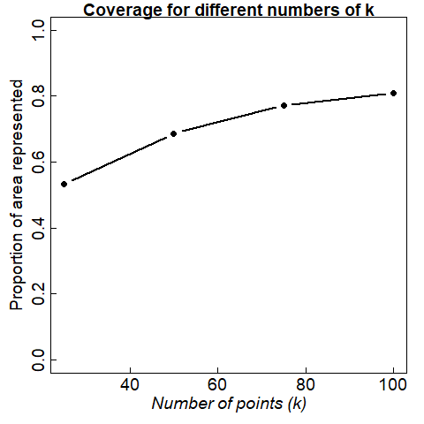

```r
# Find optimal number of points (k)
plotcoverage(results3)
```

### Verify stopping criteria

Whenever the `kpoints` function is called (directly or indirectly, as in the `choose_criteria` function), it is important to verify that stopping criteria `iter` and `min_area` are appropriate. See the Overview of the kpoints function for a more detailed description of these criteria.

You can verify stopping criteria by running the `kpoints` function with the `verify_stop` argument set to `TRUE`. This will produce a plot that allows you to visually verify that stopping criteria are appropriate, as described next.

The stopping criteria can be considered appropriate if none of `n_starts` (represented by different lines in the plot) reaches `iter` (maximum iterations) and the proportion of the study area represented levels out before stopping (without running through excessive iterations for relatively little gain in represented area). The lines in the plot below level off and then stop before reaching `iter`, indicating that the `kpoints` algorithm is able to find an optimal solution without running indefinitely. If the lines fail to level off, try increasing `iter`. If the lines level off long before `iter`, try increasing `min_area`.

```r
# Create vector of matching criteria
criteria <- c(0.7,42,3.3,66,5.4,18.4)

# Verify stopping criteria for 200 points
results1 <- kpoints(matchingvars, criteria = criteria, klist = 200,
                    n_starts = 10, min_area = 50, iter = 50,
                    raster_template = targetcells[[1]], verify_stop = TRUE,
                    savebest = FALSE)
```

[figure not shown]

## Finding final selection of subset cells using `kpoints`

Once you have determined the **matching variables**, **matching criteria**, and an optimal and feasible number of points (`k`), you should run the `kpoints` function again. This time, you should set `n_starts` to a relatively large number to have a better chance of finding a solution that will represent as large a proportion of the study area as possible (see the Overview of the kpoints function section above for details). Setting `n_starts` to 100 should be adequate, and you may choose a higher number if you wish.

```r
# Find final solution for k = 200
results1 <- kpoints(matchingvars, criteria = criteria, klist = 200,
                    n_starts = 100, min_area = 50, iter = 50,
                    raster_template = targetcells[[1]], verify_stop = FALSE,
                    savebest = FALSE)
```

## References

Hijmans, R. J. (2021). raster: Geographic Data Analysis and Modeling. R package version 3.4-13. https://CRAN.R-project.org/package=raster

MacQueen, J. (1967). Some methods for classification and analysis of multivariate observations. In Le Cam, L. M., & Neyman, J. (Eds.), *Proceedings of the Fifth Berkeley Symposium on Mathematical Statistics and Probability*. (Vol. 1, No. 14, pp. 281-297). University of California Press.

Palmquist, K. A., Bradford, J. B., Martyn, T. E., Schlaepfer, D. R., & Lauenroth, W. K. (2018). STEPWAT2: an individual-based model for exploring the impact of climate and disturbance on dryland plant communities. *Ecosphere*, 9(8). https://doi.org/10.1002/ecs2.2394

Palmquist, K. A, Schlaepfer, D. R., Martyn, T. E., Bradford, J. B., & Lauenroth, W. K. (2018). DrylandEcology/STEPWAT2: STEPWAT2 Model Description (Palmquist, et al., 2018 Ecosphere). Zenodo. https://doi.org/10.5281/zenodo.1306924

Savje, F. (2019). distances: Tools for Distance Metrics. R package version 0.1.8. https://CRAN.R-project.org/package=distances